# Mediation, Moderation & Conditional Process Analysis

Stats II · Week 11 · March 24, 2026

Hayes (2022) PROCESS Macro · Models 1, 4, 6

Today's Agenda

1

**Simple Mediation Practice**  
NSCAW/CPS Violence Study — PTSS as mediator

2

**Mediation with Covariates**  
Statistical model with q covariates

3

**Economic Stress Study**  
ESTRESS → AFFECT → WITHDRAW with 3 covariates

4

**Parallel Mediation (Model 4)**  
Multiple independent mediators — Sugar Study

5

**Serial Mediation (Model 6)**  
Mediators that cause each other

6

**Simple Moderation (Model 1)**  
PTSS × Sexual minority → Delinquency

7

**Johnson-Neyman Technique**  
Age as continuous moderator

8

**Practice Problems in R**  
Three exercises

Part 1

## Simple Mediation — Practice

NSCAW/CPS Violence Study: Does PTSS mediate violence exposure → externalizing behaviour?

NSCAW Practice — Background & Research Questions

🔬 STUDY CONTEXT

I have longitudinal data from the **NSCAW (National Survey of Child and Adolescent Well-Being)** that has information about children who have been investigated by CPS for different types of abuse or neglect.

Let's test whether: (1) children who have **witnessed severe violence at Wave 1 (EV_W1)** are more likely to engage in **externalizing behaviour at Wave 3 (bcext3)**; and (2) **post-traumatic stress at Wave 1 (tra1)** is the mechanism through which violence exposure is linked to externalizing behaviour.

[📄 Full write-up on the course website](https://bigdataforsocialjustice.github.io/stats-for-social-justice/slides/medmod/Mediation_Analysis_Results.docx)

❓ HYPOTHESES

- **H1:** Higher EV_W1 → more bcext3 at Wave 3
- **H2:** tra1 (PTSS) mediates the link

N = 1,605 children investigated by CPS | Longitudinal across multiple waves

| **X** | EV_W1 | Violence exposure severity at Wave 1 |
| --- | --- | --- |
| **M** | tra1 | Traumatic stress symptoms (PTSS) at Wave 1 |
| **Y** | bcext3 | Externalizing behaviour at Wave 3 |

EV_W1 (X) → tra1 (M) → bcext3 (Y)

🌍 WHY THIS MATTERS

If PTSS is the mechanism, trauma-focused therapy for CPS-involved children who witnessed violence could break the chain to behavioural problems.

The Simple Mediation Path Diagram

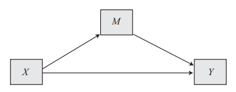

X affects Y directly AND indirectly through M

📖 READING THIS DIAGRAM

X affects Y in **two ways simultaneously:**

- **Directly** — direct effect (c'): X→Y
- **Indirectly through M** — X→M (a path) × M→Y (b path) = indirect effect (ab)

🔑 FUNDAMENTAL EQUATION

c = c′ + ab (ALWAYS)

Total = Direct + Indirect. Check this in every output.

🔑 INDIRECT EFFECT SIGNIFICANCE

NEVER use p-values for indirect effects.  
Use **bootstrapped CIs**.  
CI excludes zero → ✅ CI includes zero → ❌

Step 1 — Does Violence Exposure Predict PTSS? (The 'a path')

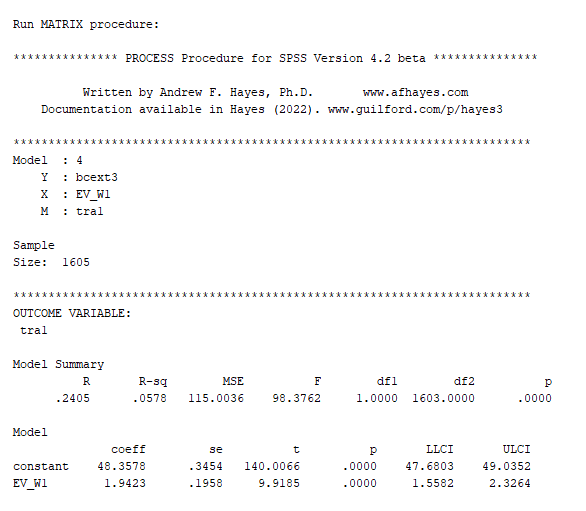

PROCESS Model 4: Y=bcext3, X=EV_W1, M=tra1 | N=1,605

📖 WHAT WE'RE TESTING

The **a path**: Does violence exposure predict PTSS? First requirement for mediation.

📖 KEY RESULT: EV_W1 = 1.9423, p < .001 ✅

Every 1-unit increase in violence → PTSS rises 1.94 points. R²=.058.  
**a path confirmed ✅**

🌍 REAL-LIFE MEANING

Children who witness more severe violence develop significantly more trauma symptoms. Violence causes PTSS — the theoretical foundation of this model.

⚠️ KEY DISTINCTION

When BOTH X and M are in the model, the X coefficient = **direct effect (c')**, NOT the total effect (c).

Step 2 — Do X and M Together Predict Externalizing? (b path + direct effect)

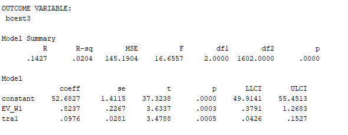

Both X and M in model → b path and direct effect c'

📖 WHAT WE'RE TESTING

b path: Does PTSS predict externalizing *controlling for* violence?  
Direct c': Does violence still predict externalizing after controlling for PTSS?

📖 KEY RESULTS

- **EV_W1 (c') = 0.8237, p=.0003 ✅**
- **tra1 (b) = 0.0976, p=.0005 ✅**

Both pathways active — required for mediation.

🌍 REAL-LIFE MEANING

Violence retains a direct effect (c'=0.82) AND trauma also independently predicts acting-out (b=0.10). Both pathways are real.

Steps 3 & 4 — Total, Direct & Indirect Effects

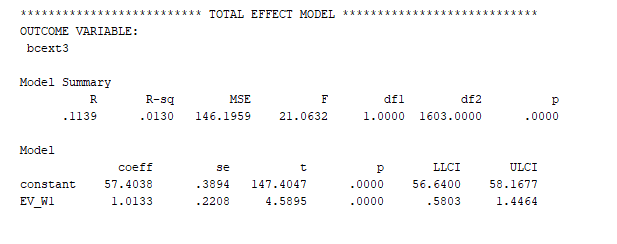

Step 3: Total effect — ignoring the mediator

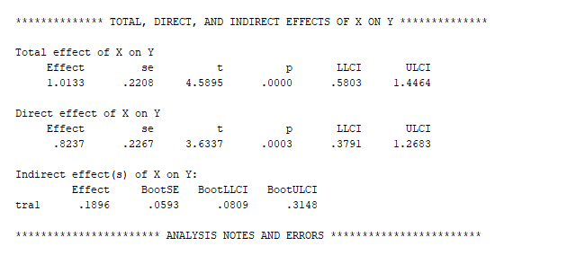

Step 4: Decomposed into direct + indirect

| Total (c) | 1.0133 | [0.58, 1.45] | ✅ |
| --- | --- | --- | --- |
| Direct (c') | 0.8237 | [0.38, 1.27] | ✅ |
| **Indirect via PTSS** | **0.1896** | **[0.08, 0.31]** | **✅ CI ≠ 0** |

✔️ MATHS CHECK

0.8237 + 0.1896 = 1.0133 ✔

🌍 CONFIRMED MEDIATOR

**18.7%** of total effect travels through trauma. Treating PTSS could reduce ~19% of downstream behavioural damage. Remaining 81% is direct — other mechanisms also exist.

Drawing Conclusions — NSCAW Violence Study

📊 THE BREAKDOWN

- Total effect = **1.0133**
- Indirect via PTSS = 0.1896 → **18.71%**
- Direct = 0.8237 → **81.29%**

PTSS is a **partial mediator**.

🔑 GOLDEN RULE

For indirect effects: bootstrapped CIs only.  
CI excludes 0 → ✅ CI includes 0 → ❌

🌍 POLICY IMPLICATION

Traumatic symptoms are the mechanism linking violence exposure to externalizing problem behaviour among CPS-involved youth.

Dealing with the child's trauma from violence exposure can reduce long-term behavioural outcomes.

Treating PTSS is necessary but NOT sufficient — the 81% direct effect means other mechanisms (neurological, social learning, disrupted attachment) also need addressing.

🎯 CHECK YOUR UNDERSTANDINGSimple Mediation — CPS Study

Total effect = 1.0133, indirect through PTSS = 0.1896. What is the direct effect?

A. 0.1896

B. 0.8237 — because c = c′ + ab → c′ = 1.0133 − 0.1896

C. 1.0133

D. Cannot calculate without more information

Click an option to check your answer

🎯 CHECK YOUR UNDERSTANDINGInterpreting Mediation Results

The indirect effect through PTSS has a 95% bootstrap CI of [0.08, 0.31]. What do you conclude?

A. Not significant — need p < .05

B. Significant — CI does not include zero

C. Borderline — CI is wide

D. Cannot conclude from a CI alone

Click an option to check your answer

Part 2

## Adding Covariates to Mediation

Interpretation stays the same — just add 'controlling for C' throughout

Covariates in Mediation — The Statistical Equations

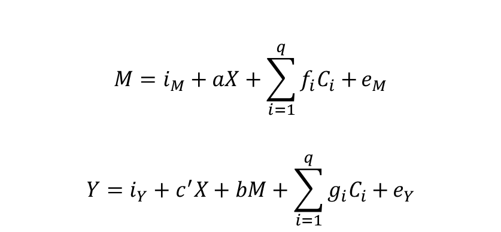

Equations with q covariates

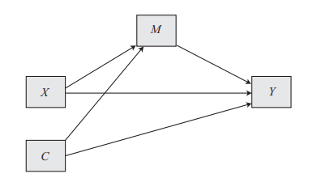

Covariates enter model alongside X

📖 EQUATION 1 — PREDICTING M

M = i<sub>M</sub> + **aX** + f₁C₁ + … + f<sub>q</sub>C<sub>q</sub> + e<sub>M</sub>

**a** = a path. **f<sub>i</sub>** = covariate effect on M.

📖 EQUATION 2 — PREDICTING Y

Y = i<sub>Y</sub> + **c′X** + **bM** + g₁C₁ + … + g<sub>q</sub>C<sub>q</sub> + e<sub>Y</sub>

**c′** = direct effect. **b** = b path.

📖 INTERPRETATION WITH COVARIATES

**Direct (c′):** Change in Y for 1-unit X, controlling for M and C.

**Indirect (ab):** X's effect through M, controlling for C.

c = c′ + ab — always. Covariates do NOT need to be in both equations.

Covariates — Why They Matter & PROCESS Options

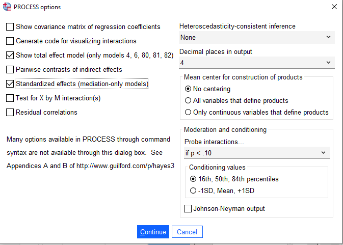

Enable: Show total effect model + Standardized effects

🔬 WHY ADD COVARIATES?

Covariates rule out alternative explanations. By controlling for C, we ensure X→M→Y reflects the genuine mechanism, not confounding by additional factors.

Covariates do **not** need to be in both equations — include wherever theoretically relevant.

📖 KEY PROCESS OPTIONS

- **Show total effect model:** prints c so you can verify c = c' + ab
- **Standardized effects:** effect sizes in SD units
- **Pairwise contrasts:** for multiple mediators

c = c′ + ab — always, with or without covariates.

🎯 CHECK YOUR UNDERSTANDINGCovariates in Mediation

Must covariates be in BOTH the M equation AND the Y equation?

A. Yes — always in both

B. No — include wherever theoretically relevant; not required in both

C. Doesn't matter

D. Yes — otherwise c = c′ + ab breaks

Click an option to check your answer

Part 3

## Economic Stress Study

ESTRESS → AFFECT → WITHDRAW — Mediation with 3 covariates (estress.sav)

Economic Stress Study — Background & Variables

🔬 STUDY CONTEXT

Participants were N=262 entrepreneurs who were members of **Business Networking International**, who responded to an online survey about their business performance and emotional reactions to the economic climate. (Pollack & Hayes)

Pollack and Hayes proposed that economic stress leads to depressed affect, which in turn enhances a business owner's intention to leave entrepreneurship. This is not a question about *whether* there is an effect, but *HOW* it operates.

❓ RESEARCH QUESTION

Does ESTRESS affect withdrawal intentions *through* depressed affect? Is AFFECT the mechanism?

ESTRESS (X) → AFFECT (M) → WITHDRAW (Y)

| **X** | ESTRESS | Economic stress — how badly the business is doing |
| --- | --- | --- |
| **M** | AFFECT | Depressed affect. Higher = more depressed. |
| **Y** | WITHDRAW | Withdrawal intentions. Higher = more likely to quit. |
| **C1** | ESE | Entrepreneurial self-efficacy |
| **C2** | SEX | Gender |
| **C3** | TENURE | Years in business |

🔮 COVARIATE HYPOTHESES

**ESE:** More confidence → less depression → less withdrawal (negative expected)  
**TENURE:** Direction genuinely unclear  
**SEX:** No strong hypothesis — '?'

Example 3 — The Statistical Model with q=3 Covariates

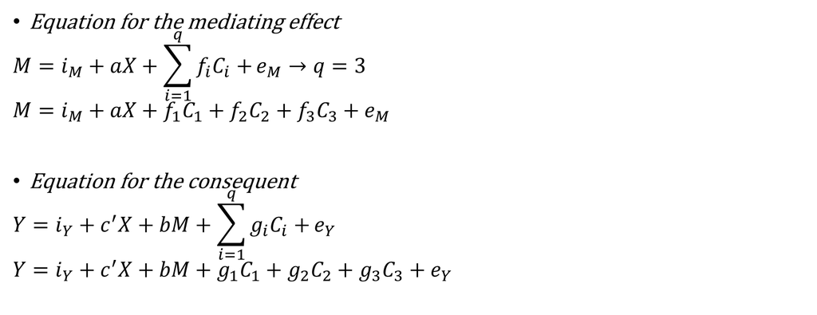

📖 EQUATION 1 — AFFECT (M)

AFFECT = i<sub>M</sub> + a(ESTRESS) + f₁(ESE) + f₂(SEX) + f₃(TENURE) + e<sub>M</sub>

**a path** = effect of ESTRESS on AFFECT holding covariates constant.

📖 EQUATION 2 — WITHDRAW (Y)

WITHDRAW = i<sub>Y</sub> + c′(ESTRESS) + b(AFFECT) + g₁(ESE) + g₂(SEX) + g₃(TENURE) + e<sub>Y</sub>

**c′** = direct effect after controlling for AFFECT and covariates.

⚠️ NOTE: Estimates will differ from simple mediation

Expected — covariates absorb variance previously attributed to X and M. Do not be alarmed.

c = c′ + ab — still holds always.

Example 3 — Statistical Path Diagram with All Covariates

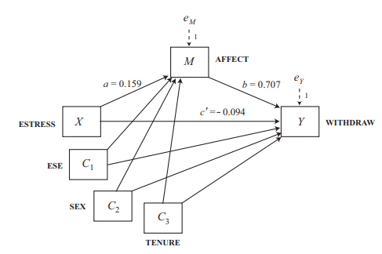

Statistical path diagram: ESTRESS→AFFECT(a=0.159)→WITHDRAW; ESE(C1), SEX(C2), TENURE(C3) all included as covariates; b=0.707, c′=−0.094

ESTRESS → AFFECT (a path with covariates)

| **estress (a path)** | **0.1593** | **<.001** | ✅ |
| --- | --- | --- | --- |
| ese (f1) | −0.1549 | .001 | ✅ |
| sex (f2) | 0.0148 | .863 | ❌ |
| tenure (f3) | −0.0108 | .086 | ❌ (trend) |

R²=.163, F=12.52, p<.001 | Outcome: AFFECT

❓ HYPOTHESES CONFIRMED?

ESE → less depression ✅ confirmed  
Tenure → unclear ✅ (marginal only)  
Gender → no effect ✅

🌍 ESTRESS (a=0.159) ✅

Every 1-unit stress increase → +0.16 more depression, controlling for gender, confidence, and experience. **a path confirmed.**

🌍 ESE (β=−0.155) ✅

Higher self-efficacy → significantly LESS depression. Confident entrepreneurs cope better.

🌍 GENDER & TENURE

Gender not significant. Tenure shows only a marginal trend (p=.086).

AFFECT → WITHDRAW (b path + direct effect c′)

| **affect (b path)** | **0.7071** | **<.001** | b path | ✅ |
| --- | --- | --- | --- | --- |
| estress (c′) | −0.0935 | .077 | Direct | ❌ |
| ese (g1) | −0.2121 | .006 | Covariate | ✅ |
| sex (g2) | 0.1274 | .378 | Covariate | ❌ |
| tenure (g3) | −0.0021 | .846 | Covariate | ❌ |

R²=.206, F=13.28, p<.001 | Outcome: WITHDRAW

🌍 AFFECT (b=0.707) ✅

Depression is a POWERFUL driver of quitting. Every 1-unit increase → 0.71 more withdrawal desire.

🌍 ESTRESS DIRECT (c′=−0.094) ❌

Once we control for depression, stress is NOT significantly related to withdrawal. The link works *through mood.*

🌍 ESE (g1=−0.212) ✅

Higher self-efficacy also directly reduces withdrawal (p=.006).

Indirect Effect — Does AFFECT Mediate Stress → Withdrawal?

| Total (c) | 0.0191 | [−.087, .126] | ❌ |
| --- | --- | --- | --- |
| Direct (c′) | −0.0935 | [−.197, .010] | ❌ |
| **Indirect via AFFECT** | **0.1127** | **[.057, .173]** | **✅** |

c = c′ + ab → 0.019 ≈ −0.094 + 0.113 ✔

⚠️ SUPPRESSION PUZZLE

How can indirect be significant if total is NOT? Direct (−0.094) and indirect (+0.113) **cancel each other out**, making the total near zero. The mediated path is real — this is a suppression effect.

🌍 MEDIATION CONFIRMED ✅

Stress → withdrawal ONLY through depression. The path: stress → depression → wanting to quit.

💡 INTERVENTION IMPLICATION

To reduce business owner burnout: treat the *depression*. Reducing stress alone may not reduce dropout rates.

📊 EFFECT SIZE

Standardized indirect = **0.1518** (~1/7th of a SD). Modest but real and actionable.

🎯 CHECK YOUR UNDERSTANDINGEconomic Stress — Suppression Effect

Total = 0.019 (n.s.). Indirect = 0.113 (sig.). How is this possible?

A. Statistical error — cannot happen

B. Direct is negative (−0.094), cancelling the positive indirect (+0.113)

C. Indirect is always larger than total

D. The CI must be wrong

Click an option to check your answer

Part 4

## Parallel Mediation — Model 4

Multiple independent mediators: The PMI Sugar Study (Example 4)

Why Simple Mediation Isn't Always Enough

⚠️ THE PROBLEM

Simple mediation assumes X influences Y through **only one mediator**. In reality, most effects operate through multiple pathways simultaneously.

Multiple Mechanisms Exist

The effect of X on Y is rarely due to just one mediator — there are usually multiple contributing factors or pathways.

Mediators Can Be Mediated

A mediator (M) may itself be influenced by another mediator, creating a chain of effects rather than a simple direct link.

Misinterpretation of Direct Effect

The 'direct effect' (c′) might reflect the combined influence of multiple unmodelled mediators, not a truly direct pathway.

✅ USE PARALLEL (Model 4) WHEN:

Multiple mediators work **independently**. Each has its own separate path from X to Y. M1 and M2 do NOT influence each other.

X → M1 → Y  
X → M2 → Y (M1 and M2 independent)

✅ USE SERIAL (Model 6) WHEN:

Multiple mediators influence each other in sequence. X → M1 → M2 → Y.

📖 KEY RULES FOR PARALLEL

X exerts its effect through **k + 1 pathways** (1 direct + k indirect). Each indirect path = specific indirect effect.

c = c′ + Σ aᵢbᵢ (always)

The Parallel Multiple Mediator Model — Theory & Formulas

📖 THE PARALLEL MODEL

Multiple mediators M₁, M₂, … Mᵢ operate **independently** — each transmits part of the effect of X on Y, but they do not influence each other.

The indirect effect through each Mᵢ = aᵢ × bᵢ, where aᵢ = X→Mᵢ and bᵢ = Mᵢ→Y, **controlling for X and all other mediators**.

📖 SPECIFIC INDIRECT EFFECTS

Each specific indirect effect reflects **only the effect through Mᵢ, controlling for all other mediators and covariates**. The model with k mediators has k specific indirect effects.

📐 THE FORMULAS

Specific indirect through Mᵢ = aᵢ × bᵢ

Total indirect = Σ aᵢbᵢ = a₁b₁ + a₂b₂ + … + aₖbₖ

c = c′ + Σ aᵢbᵢ (always!)

With k=1: reduces to c = c′ + ab

📖 CONTROLLING FOR OTHER MEDIATORS

Since parallel mediators operate independently, the **total indirect = the sum of all specific indirect effects**.

The Parallel Multiple Mediator Model — Diagrams

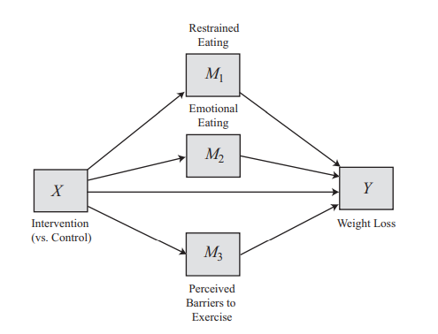

Real example: 3 independent parallel mediators

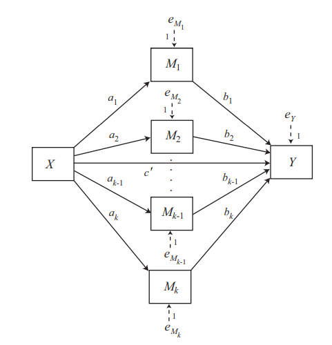

General model for k parallel mediators

📐 KEY FORMULA

Total indirect = Σ aᵢbᵢ  
c = c′ + Σ aᵢbᵢ (always!)

The Parallel Multiple Mediator Model — Total Indirect Effect

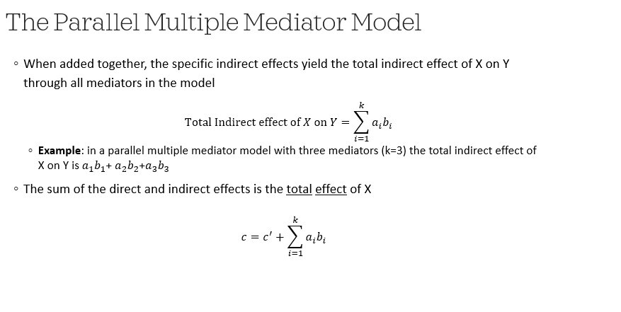

Total indirect = Σ aᵢbᵢ | Total effect: c = c′ + Σ aᵢbᵢ

📖 WHEN ADDED TOGETHER

The specific indirect effects yield the **total indirect effect** of X on Y through all mediators.

**Example with k=3:** Total = a₁b₁ + a₂b₂ + a₃b₃

📐 THE KEY EQUATIONS

Total Indirect = Σ aᵢbᵢ

c = c′ + Σ aᵢbᵢ (always!)

🔑 ALWAYS HOLDS

With 1, 2, or 10 mediators — total = direct + ALL specific indirect effects. If numbers don't add up, check your model.

Sugar Study — Full Background, Variables & Research Question

🔬 STUDY CONTEXT

N=123 Israelis (43 male, 80 female) read an article about a potential sugar shortage. Half (n=58) were told it would appear on the **FRONT PAGE** of a major newspaper; half (n=65) were told it was in the **MIDDLE OF AN ECONOMIC SUPPLEMENT**. Same article — only described placement differed.

Participants reported their intention to buy sugar (REACTION) and their belief that others would be influenced by the media (PMI).

❓ RESEARCH HYPOTHESIS

Front-page placement doesn't directly drive buying. It works through two psychological mechanisms:

1. **IMPORT:** 'Front page = this shortage must be serious'
2. **PMI:** 'Everyone will panic-buy — I should too' (bandwagon)

| **X** | COND | 1=front page, 0=interior |
| --- | --- | --- |
| **M1** | IMPORT | Perceived importance of the article |
| **M2** | PMI | Presumed media influence — belief others will be influenced |
| **Y** | REACTION | Intention to buy sugar |

COND (X) → IMPORT (M1) → REACTION (Y)  
COND (X) → PMI (M2) → REACTION (Y)

Interpreting the Mediation Effect — Two Ways

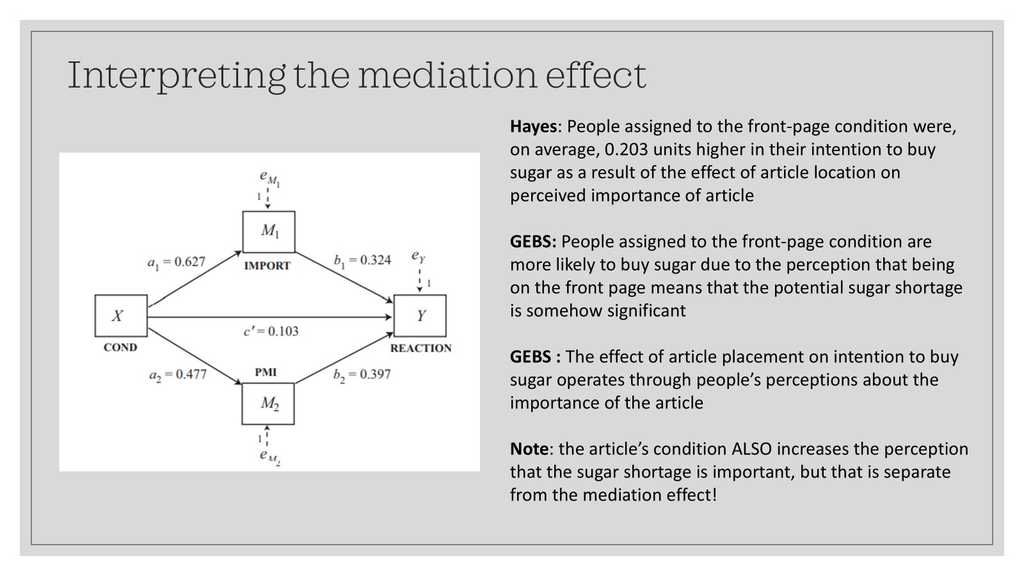

Two ways to interpret the mediation effect — Hayes textbook style vs plain English (GEBS)

Parallel Mediation — M Equation Outputs (PMI and IMPORT)

📖 PMI (M2): a2 = 0.4765, p=.0454 ✅

Front-page placement significantly increases presumed media influence. 'Everyone will be influenced by this.'

📖 IMPORT (M1): a1 = 0.6268, p=.0452 ✅

Front-page placement significantly increases perceived importance. 'This shortage must be serious.'

⚠️ SAME AS SINGLE MEDIATION MODEL

These estimates are **the same** as the single mediation model. The M equations are unchanged regardless of how many mediators you add. The difference shows up only in the Y equation and indirect effects.

🌍 BOTH a PATHS CONFIRMED ✅

Both psychological mechanisms are activated by front-page placement. First requirement for parallel mediation met.

Parallel Mediation — M Equation PROCESS Output (PMI and IMPORT)

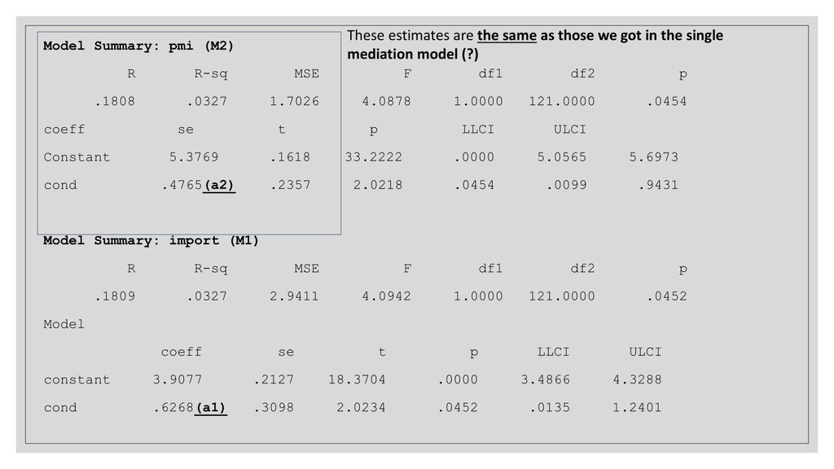

PROCESS output for both M equations — note: same estimates as single mediation model

Parallel Mediation — Y Equation (REACTION)

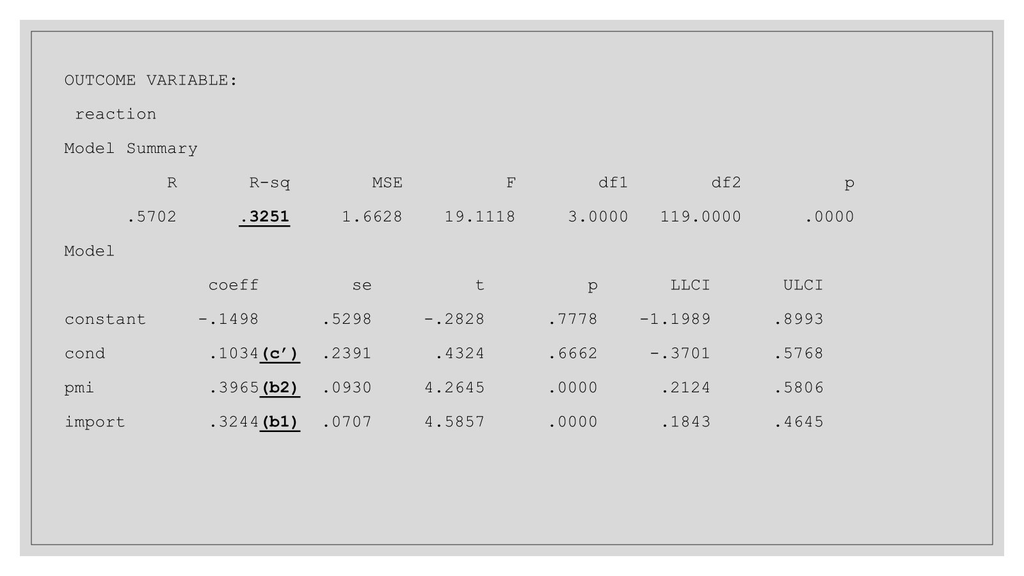

PROCESS output: Y equation | R²=.3251, F=19.11, p<.001

📖 READING THE OUTPUT

**cond (c′) = 0.1034, p=.666 ❌**  
Article placement does NOT directly affect buying.

**pmi (b2) = 0.3965, p < .001 ✅**

**import (b1) = 0.3244, p < .001 ✅**

🌍 THE PSYCHOLOGICAL MECHANISMS DO ALL THE WORK

The direct effect is non-significant. Seeing the front-page headline does NOT directly make you want to buy sugar. It works entirely THROUGH the psychological mediators.

Parallel Mediation — Direct Effect of X on Y

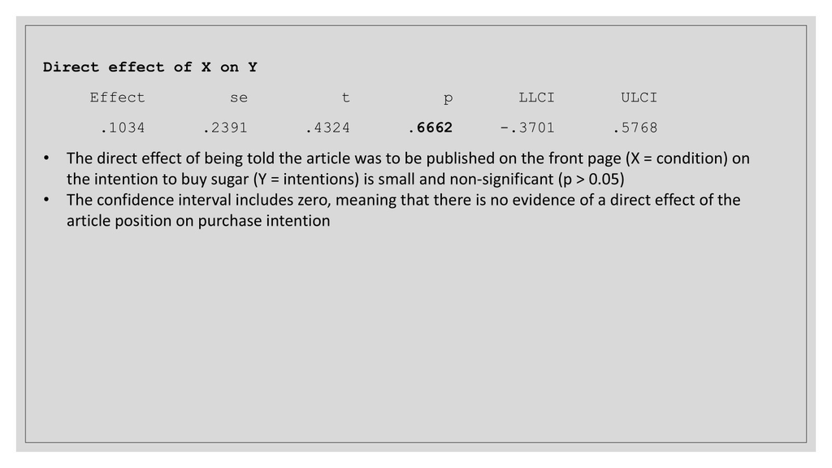

Direct effect output from PROCESS

📖 READING THE OUTPUT

Direct effect (c′) = 0.1034, p = .6662, CI [−.3701, .5768]

The CI **includes zero → not significant**.

🌍 WHAT THIS MEANS

The direct effect of being told the article would be published on the front page (X) on the intention to buy sugar (Y) is small and non-significant (p > 0.05).

The confidence interval includes zero, meaning there is no evidence of a direct effect of article position on purchase intention. All effect works **indirectly through the psychological mediators**.

Parallel Mediation — Indirect Effects of X on Y

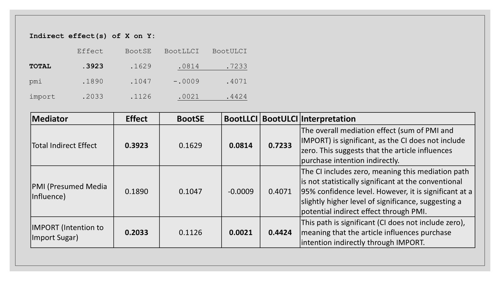

Indirect effects output with full interpretation table

📖 KEY RESULTS

**TOTAL = 0.3923, CI [.0814, .7233] ✅**  
Overall mediation is significant.

**PMI = 0.1890, CI [−.0009, .4071] ⚠️**  
Borderline — CI barely includes zero.

**IMPORT = 0.2033, CI [.0021, .4424] ✅**  
Significant — CI excludes zero.

🔑 RULE

Bootstrapped CIs only.  
CI excludes 0 → ✅ CI includes 0 → ❌

Interpreting the Indirect Effects — The Full Calculation

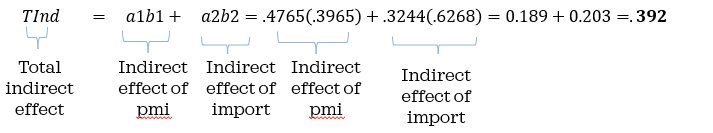

Interpreting the Indirect Effects

📖 TOTAL INDIRECT (0.392)

People in the front-page condition had an intention to buy sugar that was 0.392 units higher due to the article's influence on the mediators, which in turn affected their purchase intention.

🌍 PMI (0.189) & IMPORT (0.203)

**PMI:** 0.189 units higher because placement influenced their perception of media importance, which affected purchase intention.  
**IMPORT:** 0.203 units higher due to its influence on their perception of article importance, which shaped their intention to purchase sugar.

Sugar Study — Statistical Diagram with All Coefficients

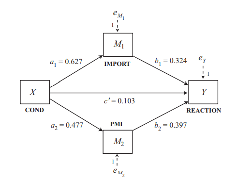

All path coefficients from the parallel mediation model

📖 THE COEFFICIENTS

- **a1=0.627:** front page → more perceived importance
- **a2=0.477:** front page → more PMI
- **b1=0.324:** importance → more buying
- **b2=0.397:** PMI → more buying
- **c'=0.103:** direct (NOT significant)

📐 CALCULATE

Indirect IMPORT: 0.627×0.324 = **0.203 ✅**  
Indirect PMI: 0.477×0.397 = **0.189 ⚠️**  
Direct: 0.103 ❌

0.103+0.203+0.189 = 0.495 ≈ total ✔

Simple vs. Parallel Mediation — Published CPA Example

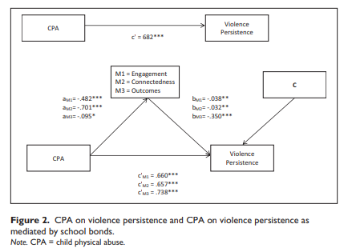

Fig. 2: Simple mediation — all bonds combined

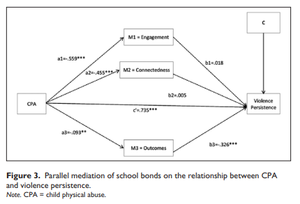

Fig. 3: Parallel mediation — three separate pathways

🌍 WHY PARALLEL IS MORE INFORMATIVE

🎯 CHECK YOUR UNDERSTANDINGParallel Mediation — Sugar Study

IMPORT indirect = 0.203 (CI: [.002, .442]). PMI indirect = 0.189 (CI: [−.001, .407]). Which is stronger?

A. IMPORT — 0.203 is larger

B. PMI — wider CI

C. Cannot conclude — contrast CI includes zero

D. Neither — PMI is non-significant

Click an option to check your answer

Part 5

## Serial Mediation — Model 6

What if the mediators cause each other? Testing X → M1 → M2 → Y

Serial Mediation — Definition & Key Concepts

📖 WHAT IS SERIAL MEDIATION?

Serial mediation **rejects the assumption that mediators are independent** — instead, it models causal relationships between mediators.

X first influences M1, which then affects M2, and so on, ultimately influencing Y. The goal is to model a **stepwise causal process**.

🌍 SCHOOL BONDING EXAMPLE

**Parallel:** school attachment (M1) and academic achievement (M2) independently mediate CPA → violence.

**Serial:** child maltreatment reduces school attachment (M1), which then lowers academic achievement (M2), ultimately influencing bad outcomes (Y). **M1 CAUSES M2.**

📖 THE SERIAL CHAIN

X → M1 → M2 → Y

| M's cause each other? | ❌ No | ✅ Yes |
| --- | --- | --- |
| Order matters? | ❌ No | ✅ Critical |
| New unique path? | None | X→M1→M2→Y |
| PROCESS model | 4 | 6 |

🔑 THE NEW PATH: Ind3 = a₁ × d₂₁ × b₂

d₂₁ = the M1→M2 coefficient. ONLY exists in serial mediation. Cannot be tested with parallel (Model 4).

Key Differences Between Serial and Parallel Mediation

📖 WHAT THEY SHARE

In both models, the **total effect of X on Y is partitioned into direct and indirect effects**. Part of X's influence occurs directly, part indirectly through mediators.

Regression weights represent the strength of relationships at each step. These coefficients estimate the expected difference in Y for a one-unit change in X, as it propagates through the mediators.

📖 WHAT MAKES SERIAL DIFFERENT

- Mediators influence each other in a causal sequence
- The **order of mediators matters** — entry order defines your causal hypothesis
- Total indirect includes the chain path: X→M1→M2→Y (Ind3)
- Serial = **Model 6** | Parallel = **Model 4**

| Total = direct + indirect | ✅ Yes | ✅ Yes |
| --- | --- | --- |
| Order of M's matters | ❌ No | ✅ Yes |
| Ind3 = a₁×d₂₁×b₂ | ❌ No | ✅ Yes |
| M's independent | ✅ Yes | ❌ No |

📐 THREE INDIRECT EFFECTS (2 mediators)

**Ind1:** X→M1→Y = a₁ × b₁  
**Ind2:** X→M2→Y = a₂ × b₂  
**Ind3 (NEW!):** X→M1→M2→Y = a₁ × d₂₁ × b₂

🔑 THEORY DRIVES THE CHOICE

M1 causes M2 → serial (Model 6).  
M1 and M2 independent → parallel (Model 4).

Child Maltreatment, School Bonds & Adult Violence: A Serial Mediation Model

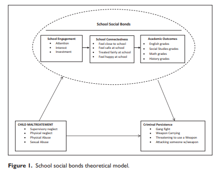

Fig. 1: Theoretical model — the serial cascade from abuse to adult violence

📊 HYPOTHESIS 1

Physically abused children will have lower school connectedness, engagement, and achievement, and will be more likely to persist in violent behaviour as adults (direct effect between CPA and adult violence).

📊 HYPOTHESIS 2

School characteristics will both **independently**, **jointly**, and **serially** mediate the relationship between CPA and persistence in adult violence.

📊 HYPOTHESIS 3

Gender will **moderate** the mediation effect of school characteristics on the CPA → adult violence relationship.

Two-Mediator Serial Model — Statistical Diagram

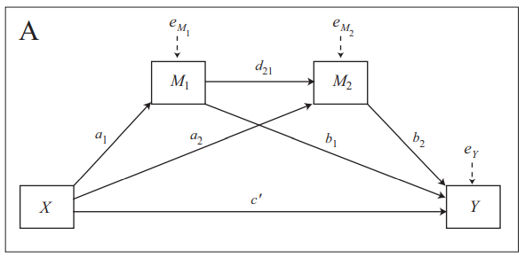

Statistical diagram: d21 = M1→M2 arrow — the defining feature of serial mediation

Two-Mediator Serial Model — Conceptual & Statistical Diagrams

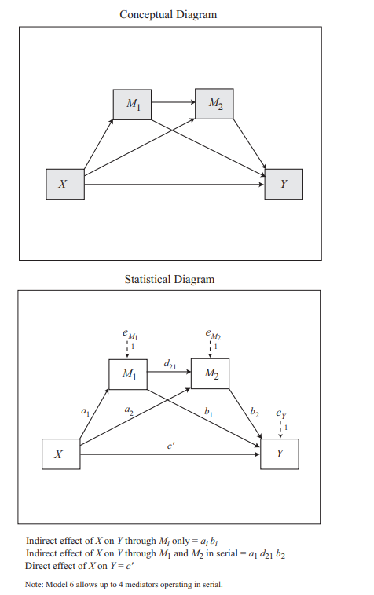

Conceptual + statistical diagrams with formulas: Ind1=a1b1; Ind3=a1·d21·b2

📖 THREE INDIRECT EFFECTS

**Ind1:** X→M1→Y = a₁ × b₁  
**Ind2:** X→M2→Y = a₂ × b₂  
**Ind3 (NEW!):** X→M1→M2→Y = a₁ × d₂₁ × b₂

🔑 IND3 IS THE NEW PATH

Ind3 = a₁ × d₂₁ × b₂ captures the COMPLETE SERIAL CHAIN: X → M1 → M2 → Y. This path can ONLY be tested with serial mediation (Model 6). It is the unique contribution of the serial model.

📖 WHAT d₂₁ MEANS

d₂₁ is the coefficient on the M1→M2 arrow. It estimates how much M1 influences M2. Without this path you have parallel mediation. With it tested, you have serial.

Simple vs. Serial Mediation — CPA Published Example

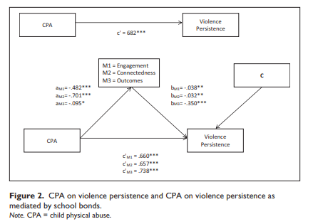

Simple mediation (limited)

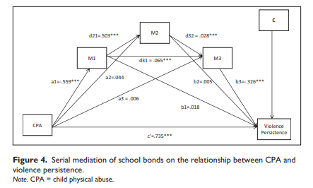

Fig. 4: Serial model — M1→M2→M3 chain revealed

📖 WHAT THE SERIAL MODEL ADDS

The serial model adds d21=.503*** — school engagement significantly predicts connectedness. That cascade is the theoretical mechanism. Parallel mediation would miss it entirely.

Take the Output ONE Step at a Time!

[figure not shown]

📋 THE FOUR STEPS

1. **Step 1:** Does X → IMPORT (M1)? Check a1 and CI.
2. **Step 2:** Does IMPORT → PMI (d21)? Does X still predict PMI (a2)?
3. **Step 3:** Do IMPORT and PMI → REACTION? Check b1, b2, and c′.
4. **Step 4:** Examine Ind1, Ind2, Ind3 and contrast tests.

🔑 MODEL 6 SETUP

Enter mediators in **causal order** — IMPORT first (M1), PMI second (M2). Order is critical! Reversing tests a completely different theory.

Serial Model Results — Statistical Diagram with Coefficients

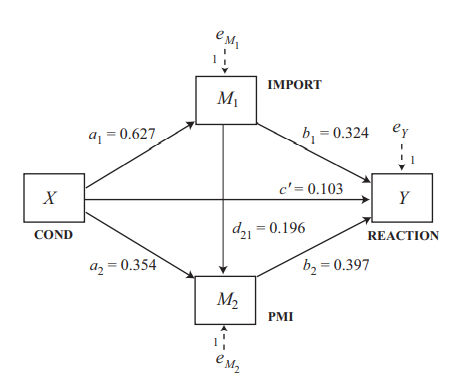

d21=0.196, p=.004 *** — the serial chain is confirmed

STEP 1: COND → IMPORT (a1=0.627, p=.045) ✅

Front-page placement significantly increases perceived importance.

STEP 2: IMPORT → PMI (d21) — THE SERIAL LINK

**a2 (COND→PMI directly): β=0.354, p=.131 ❌** Not significant once IMPORT included.

**d21 (IMPORT→PMI): β=0.196, p=.004 ✅** The serial chain is confirmed!

STEP 3: Both → REACTION

b1(IMPORT)=0.324*** ✅ b2(PMI)=0.397*** ✅  
c′(COND direct)=0.103, p=.666 ❌

Serial Mediation — Three Indirect Effects (Step 4)

| Total indirect |  | 0.392 | [.084, .733] | ✅ |
| --- | --- | --- | --- | --- |
| Ind1: COND→IMPORT→Y | a₁×b₁ | 0.203 | [.000, .453] | ✅ |
| Ind2: COND→PMI→Y | a₂×b₂ | 0.140 | [−.050, .350] | ❌ |
| **Ind3: COND→IMPORT→PMI→Y** | **a₁×d₂₁×b₂** | **0.049** | [−.000, .137] | ⚠️ |

📖 Ind3 = 0.627 × 0.196 × 0.397 = 0.049

Borderline with N=123. This is the unique finding only serial mediation can test.

🌍 Ind1 ✅: 'This is serious' → buy sugar

Front page → perceived importance → buying. Confirmed.

🌍 Ind2 ❌: PMI alone doesn't hold up

Not a significant standalone pathway when serial structure is modelled.

🌍 Ind3 ⚠️: THE SERIAL CHAIN

Front page → importance → bandwagon → buy sugar. Full cascade exists. Borderline due to small N. Theoretically the most interesting finding.

📊 CONTRASTS: No pathway is significantly stronger

All contrast CIs include 0. Bigger numbers ≠ significantly different effects.

Contrast Tests & Combining Parallel + Serial Models

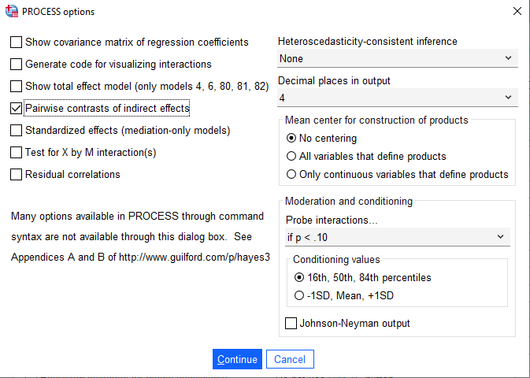

Enable 'Pairwise contrasts of indirect effects' in PROCESS options

| Contrast | Comparison | Diff. | 95% CI |
| --- | --- | --- | --- |
| C1 | Ind1 − Ind2 | 0.063 | [−.231, .390] |
| C2 | Ind1 − Ind3 | 0.155 | [−.004, .383] |
| C3 | Ind2 − Ind3 | 0.092 | [−.121, .322] |

📖 RESULT: ALL CIs INCLUDE ZERO

No pathway is significantly stronger than another. With N=123, not enough power to detect pathway differences. Bigger numbers ≠ significantly different effects.

📖 WHAT CONTRASTS TEST

Is one indirect pathway significantly *stronger* than another? Just because Ind1 (0.203) looks bigger than Ind3 (0.049) numerically doesn't mean it's statistically stronger.

You need to run the pairwise contrast tests and check whether the difference CI excludes zero before concluding one mediator is stronger.

🔑 KEY LESSON

Always use confidence intervals to compare indirect effects, never raw estimates alone.

See next slide for combining parallel + serial models (Model 81).

Combining Parallel + Serial Models — Model 81

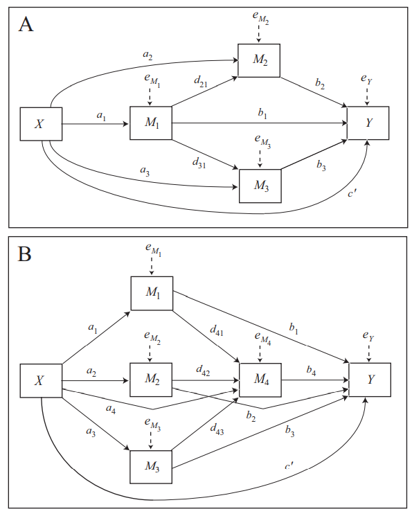

Model 81: Model A (M1 serial with M2+M3 parallel) and Model B (M1/M2/M3 parallel feeding M4 serially)

🔑 MODEL 81

PROCESS can estimate models with BOTH parallel AND serial mediators simultaneously.

Model A: M1 is serial with M2, but M2 and M3 are parallel to each other.

Model B: M1/M2/M3 all parallel, all feed into M4 serially.

Look through the dozens of options in the Hayes book appendix for the right configuration for your theory.

💡 THE POINT

Mediation doesn't have to be purely parallel OR purely serial. Real theoretical models are often combinations — and PROCESS has pre-programmed templates for dozens of configurations.

🎯 CHECK YOUR UNDERSTANDINGSerial Mediation — The New Path

In a two-mediator serial model, what is the formula for Ind3?

A. a₁ × b₁

B. a₁ × b₂

C. a₁ × d₂₁ × b₂ — X to M1, M1 to M2, M2 to Y

D. a₂ × b₂

Click an option to check your answer

🎯 CHECK YOUR UNDERSTANDINGSerial vs. Parallel — Which Model?

Researcher believes: trauma (X) → anxiety (M1), anxiety causes poor sleep (M2), poor sleep → poor health (Y). Which model?

A. Parallel mediation

B. Serial mediation — anxiety causes poor sleep

C. Simple mediation

D. Moderation

Click an option to check your answer

Part 6